# Progetto di Fondamenti di Scienza dei Dati

Denis Gasparollo

2022-09-01

Nella cronaca di questi ultimi 2 anni si è parlato molto di attacchi informatici, soprattutto di tipo ransomware con annesso data breach, e il loro numero è aumentato in tutti i settori mettendo così in luce lo scarso livello di sicurezza dei sistemi informatici(configurazione non corretta degli apparati, sistemi operativi e softwares non mantenuti aggiornati, non si sfruttano sistemi IDS, …).

I datasets presi in considerazione sono 3 e trattano principalmete i data breach avvenuti tra il 2004 e il 2022:

- [link](https://espace.library.uq.edu.au/view/UQ:dfe5027) il quale contiene informazioni su data breach e ransomware tra il 2004 e l’inizio del 2020 raccolti dall’università del Queensland;
- [link](https://en.wikipedia.org/wiki/List_of_data_breaches), che non è che il risultato di uno scrapping (per lo scrapping della pagina vedi script nel file *wiki_scrap.R*);
- [link](https://docs.google.com/spreadsheets/d/1Je-YUdnhjQJO_13r8iTeRxpU2pBKuV6RVRHoYCgiMfg/edit#gid=322165570) spreadsheet online.

Il secondo e il terzo dataset sono quelli più semplici e contengono informazioni generali di un attacco, ad esempio anno, nome dell’azienda, quantità di record rubati, ecc; invece il primo può essere suddiviso in 4 sezioni: la prima riguarda una sorta di profilo dell’azienda a livello generale (nome dell’azieda, dimensione dell’azienda, il settore, …), la secondo contiene le carattereristiche dell’attacco (data, record rubati, tipo e vettore di attacco), la terza contiene i sistemi di sicurezza implementati nel sistema informatico e, infine, la quarta e ultima contiene le conseguenze dell’attacco (se è avvenuto o meno un leak di qualche tipo di informazione esfiltrata dall’azienda, se ci sono stati provvedimenti di qualunque tipo, …).

```r
library(readr)
library(tidyr)
library(ggplot2)
library(dplyr)
library(modelr)
library(stringr)
library(rcompanion)
library(gridExtra)
library(DT)
library(corrplot)
```

# IMPORT DEI DATI

Il primo dataset è composto da 43 features e 1145 osservazioni, il sencondo da 6 features e 353 osservazioni e l’ultimo da 19 features e 263 osservazioni.

```r
# lettura dati
queensland <- read_delim("data/dataset.csv", delim = ';', na = c("Unknown", "Missing", "NA"))
wiki <- read_csv("data/wiki.csv", na = "unknown")
data_breaches_2018_update <- read_csv("data/Data Breaches - 2018 update.csv",comment = "#")
```

Si sfrutta la funzione ‘read_delim()’ per il fatto che il CSV una il punto e virgola come delimitatore.

## FEATURES

```r
names(queensland)
```

```
##  [1] "Year"
##  [2] "Organisation"
##  [3] "Critical Industry"
##  [4] "Organisation size"
##  [5] "Level of digital intensity"
##  [6] "Sector"
##  [7] "Country"
##  [8] "Cyber security role"
##  [9] "Cyber security frameworks"
## [10] "Education and awareness policy"
## [11] "Policy"
## [12] "Prevention, Detection and Recovery"
## [13] "Improper network segmentation"
## [14] "Inappropriate remote access"
## [15] "Absence of encryption"
```

[output cut: 29 more lines]

```r
names(wiki)
```

```
## [1] "Entity"            "Year"              "Records"
## [4] "Organization type" "Method"            "Sources"
```

```r
names(data_breaches_2018_update)
```

```
##  [1] "Entity"               "alternative name"     "story"
##  [4] "YEAR"                 "YEAR(2)"              "records lost"
##  [7] "ORGANISATION"         "METHOD OF LEAK"       "NO OF RECORDS STOLEN"
## [10] "DATA SENSITIVITY"     "1st source link"      "2nd source link"
## [13] "3rd source"           "source name"          "interesting story"
## [16] "UNUSED...16"          "UNUSED...17"          "Exclude"
## [19] "...19"
```

# NORMALIZZAZIONE

```r
queensland %>% group_by(`Effect on share price`) %>%
  summarise(count = n())
```

```
## # A tibble: 4 × 2
##   `Effect on share price` count
##   <chr>                   <int>
## 1 ↑                           8
## 2 ↓                          54
## 3 No change                  51
## 4 <NA>                     1032
```

```r
queensland <- queensland %>% select(c(-...44, -`Effect on share price`, -`Overall nature of attack`)) %>%
  mutate(`Number of users affected` = as.numeric(`Number of users affected`))
```

```r
wiki <- wiki %>% select(-Sources)
```

- *Sources* è stato escluso perchè contiene collegmaneti ipertestuali.

```r
data_breaches_2018_update <- data_breaches_2018_update %>%
  select(c(Entity : `1st source link`, `source name`, -YEAR, -`NO OF RECORDS STOLEN`)) %>%
  rename(YEAR = `YEAR(2)`)
```

- *NO OF RECORDS STOLEN* è stato tolto perchè si ripete con il campo *record lost*;
- *YEAR* è stato rimosso perchè fornisce una rappresentazione alternativa per l’anno: valore numerico compreso tra 0 (2004) e 14 (2018);
- *interesting story*, *UNUSED…16*, *UNUSED…17* e *Exclude* vengono esclusi perchè per la maggior parte delle osservazioni i valori non sono disponibili;
- *…19* è un errore di esportazione a csv dal foglio excell.

# DOMANDE

1. Come sono cresciuti gli attacchi con il passare degli anni?
2. Qual’è il settore che è stato maggiormente colpito?
3. Com’è cresciuto il volume di dati esfiltrati con il passare del tempo?
4. Che relazione esite tra sistemi di sicurezza implementati e le conseguenze di tale attacco?

## Come sono cresciuti gli attacchi con il passare degli anni?

```r
split_date <- function(){
  res <- list()

  for(year in wiki$Year)
    res <- c(res, as.numeric(str_split(year, "-")[[1]][1]))

  return(unlist(res))
}
```

La funzione descritta in precedenza serve nel caso in cui l’anno di avvenimento dell’attacco non è definito da un singolo anno ma da due anni separati del carattere “-” (come mostrato di seguito), per il fatto che, probabilemete, tale attacco è avvenuto a cavallo degli anni espressi, e prendo in considerazione solo l’anno in cui è iniziato l’attacco.

```r
wiki %>% select(Year) %>%
  filter(nchar(Year) > 4)
```

```
## # A tibble: 3 × 1
##   Year
##   <chr>
## 1 2019-2020
## 2 2018-2019
## 3 2014-2015
```

Dai 3 dataset vado ad estrarre le features che riguardano il nome dell’azienda che è stata vittima dell’attacco o data-breach, l’anno, il paese, il settore di competenza e le tecniche di attacco.

Lo scopo di estrarre tali features è quello di andare a studiare la crescita o la diminuzione del numero di attacchi condensando il tutto in una singola tabella.

```r
wiki_attacks <- wiki %>% select(c(Year, Entity, `Organization type`, Method, Records)) %>%
  rename(Sector = `Organization type`, `Attack type` = Method) %>%
  mutate(Year = as.numeric(split_date()), Records = as.numeric(str_remove_all(wiki$Records, ",")))


data_breaches_2018_update_attacks <- data_breaches_2018_update %>%
  select(c(YEAR, Entity, ORGANISATION, `METHOD OF LEAK`, `records lost`)) %>%
  rename(Year = YEAR, Sector = ORGANISATION, `Attack type` = `METHOD OF LEAK`, Records = `records lost`)

queensland_attacks <- queensland %>% select(c(Year, Organisation, Sector, `Attack type`, `Number of users affected`)) %>%
  rename(Entity = Organisation, Records = `Number of users affected`)

attacks <- union_all(union_all(wiki_attacks, data_breaches_2018_update_attacks), queensland_attacks) %>%
  filter(!is.na(Year))
```

```r
#grafico andamento del numero di attacchi in funzione del tempo
(attack_year <- attacks %>% group_by(Year) %>%
  summarise(attack = n()))
```

```
## # A tibble: 19 × 2
##     Year attack
##    <dbl>  <int>
##  1  2004      5
##  2  2005     30
##  3  2006     43
##  4  2007     61
##  5  2008     64
##  6  2009     51
##  7  2010     70
##  8  2011    110
##  9  2012    110
## 10  2013    185
## 11  2014    159
## 12  2015    140
## 13  2016    208
## 14  2017    267
## 15  2018    179
## 16  2019     57
## 17  2020     33
## 18  2021     13
## 19  2022      6
```

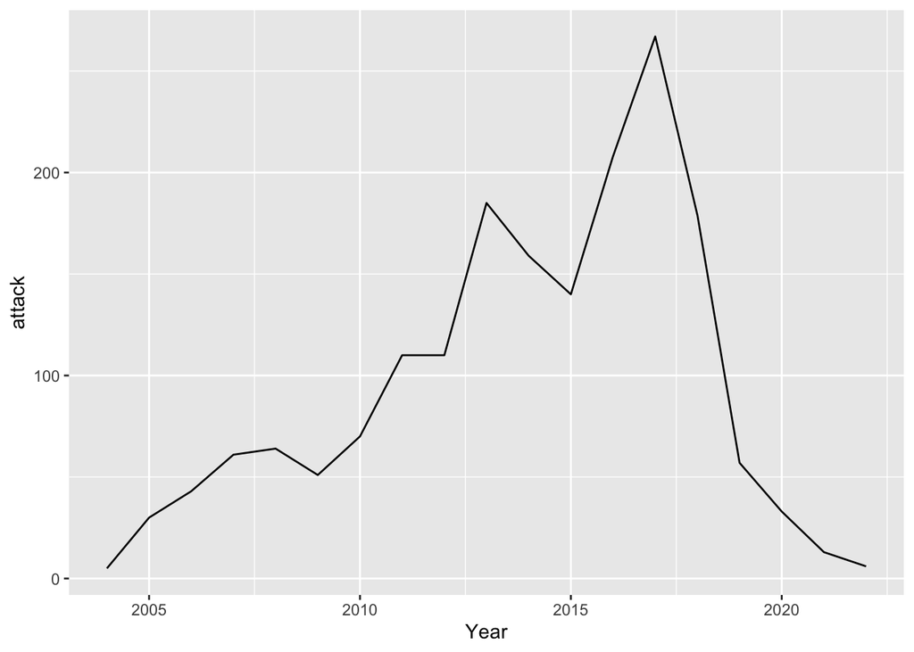

```r
ggplot(attack_year, aes(x = Year, y = attack, )) +
  geom_line()
```

Dal grafico quà sopra si vede che fino al 2017 il numero di attacchi è aumentato fino a un numero di attacchi pari a 267 in un anno, per poi scendere negli anni successivi. Dal 2019 fino ad oggi c’è stata una riduzione non indifferente che probabilmete è stata portata da un aumento della sensibilizzazione da parte delle aziende nell’ambito della sicurezza e cybersecurity data anche per il fatto che con il COVID-19 ha portato molte aziende ad approcciarsi con lo smart working, necessitando di un maggior livello di sicurezza.

## Qual’è il settore che è stato maggiormente colpito?

```r
#grafico andamento del numero di attacchi in funzione al settore
attack_sector <- attacks %>%
  group_by(Sector) %>%
  summarise(attacks = n()) %>%
  filter(attacks > 30) %>%
  arrange(-attacks)

attack_sector
```

```
## # A tibble: 16 × 2
##    Sector                                    attacks
##    <chr>                                       <int>
##  1 Human health activities                       318
##  2 web                                           137
##  3 Finance and insurance                         122
##  4 Education                                     101
##  5 Wholesale, retail trade and repair            100
##  6 healthcare                                     85
##  7 Arts, entertainment and recreation             72
##  8 financial                                      71
##  9 government                                     70
## 10 IT and other information services              63
## 11 Accommodation and food service activities      60
## 12 Public administration and defence              56
## 13 retail                                         46
## 14 Advertising and other business services        34
## 15 Legal and accounting activities                31
## 16 tech                                           31
```

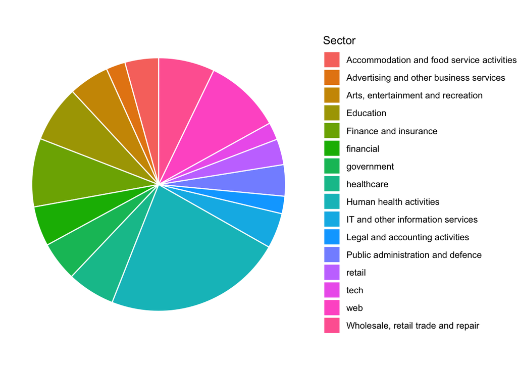

```r
attack_sector %>% ggplot() +
  geom_bar(aes(x = "", y = attacks, fill = Sector), stat = "identity", color = "white") +
  coord_polar("y", start = 0) +
  theme_void()
```

Da come viene mostrato dal grafico soprastante il settore che è stato maggiormente colpito è quello delle **Human health activities** con un totale di 318 attacchi il quale risulta più del doppio del settore subito sotto, che è quello del **web** con un totale di 137 attacchi dal 2004 al 2022.

### Perchè il settore *Human health activities* è quello maggiormente attaccato?

Qui di seguito proviamo a capire perchè il settore delle **Human health activities** è quello che è stato maggiormente preso di mira in questi 18 anni.

Per fare questo vado a prendere in considerazione i sistemi di sicurezza di tutte le aziende che lavorano nel settore sopracitato e guardo cosa hanno in comune.

```r
health <- queensland %>% filter(Sector == "Human health activities") %>%
    select(c(`Critical Industry`,
             `Organisation size`,
             `Level of digital intensity`,
             `Cyber security role` : `Additional disclosure of information`,
             -Detector, `Attack type`, `Attack vector`))
```

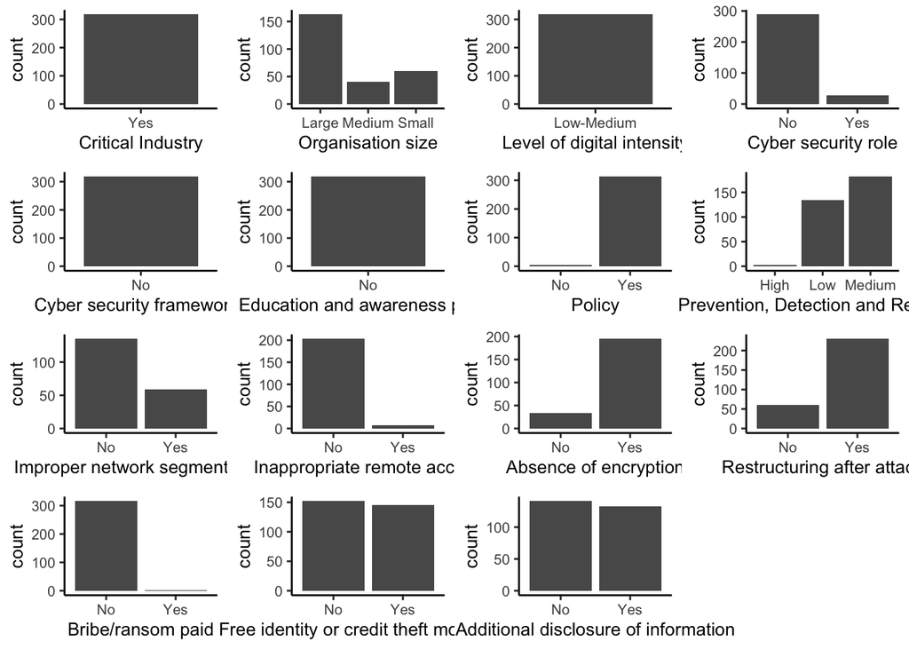

```r
plots <- list()

for (feature in names(health %>% select(-`Attack type`, -`Attack vector`))) {
  plots[[feature]] <- health %>%
    filter(!is.na(!!as.symbol(feature))) %>%
    group_by(!!as.symbol(feature)) %>%
    ggplot(aes(x = !!as.symbol(feature))) +
    geom_bar() +
    theme_classic() +
    theme(text = element_text(size = 10), legend.position = "none")
}

do.call("grid.arrange", c(plots, ncol = 4))
```

La prima cosa che scatta all’occhio che, senza alcun dubbio, il settore sanitario costituisce un settore critico e che, ovviamente, non ha un ruolo inerente alla cybersecurity. In generale a livello di sistemi di sicurezza il settore è messo abbastanza bene ma ci sono un paio di cose che saltano all’occhio: uno dei modi principali per effettuare attacchi è sfruttare l’accesso remoto e in questo caso tali accessi sono protetti, nel maggior numero dei casi, appropriamente, ma la cosa più preoccupante che circa 200 aziende non usano la cifratura e in nessuna di queste ha una politica di educazione e sensibilizzazione del personale e non usano alcun cybersecurity framework il quale fornisce delle linee guida e le best practice per ottenere un sistema sicura.

Da questa analisi si potrebbe dedurre che il fatto dell’assenza di cifratura potrebbe essere una delle causa di un eventuale pubblicazione dei dati esfiltrati illecitamente, ma non spiega il perchè dell’attacco.

L’unica motivazione di questo numero spropositato di attacchi potrebbe essere causato dalla mancanza di una politica di educazione e sensibilizzazione dello staff alle possibile problematica di sicurezza informatica che potrebbero incontrare durante lo svolgimento del lavoro (mail di phishing, allegati alle mail, …) e di come proteggersi da esse, con lo scopo di ridurre la possibilità attacco che è stato causato da un fattore umano.

### Il fattore umano è davvero la causa principale di attacco nel settore?

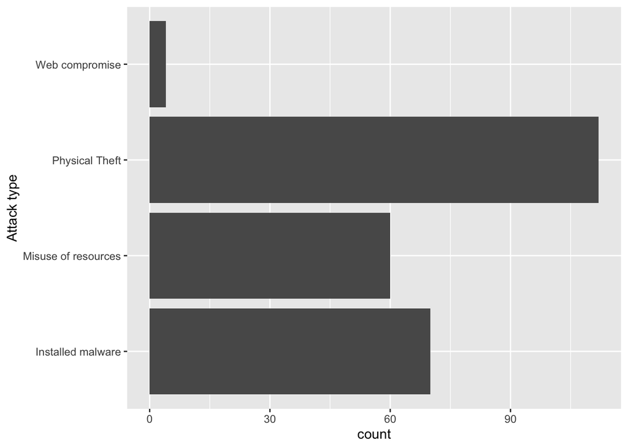

```r
#Tipo di attacco
health %>% filter(!is.na(`Attack type`)) %>%
  ggplot(aes(y = `Attack type`)) +
  geom_bar()
```

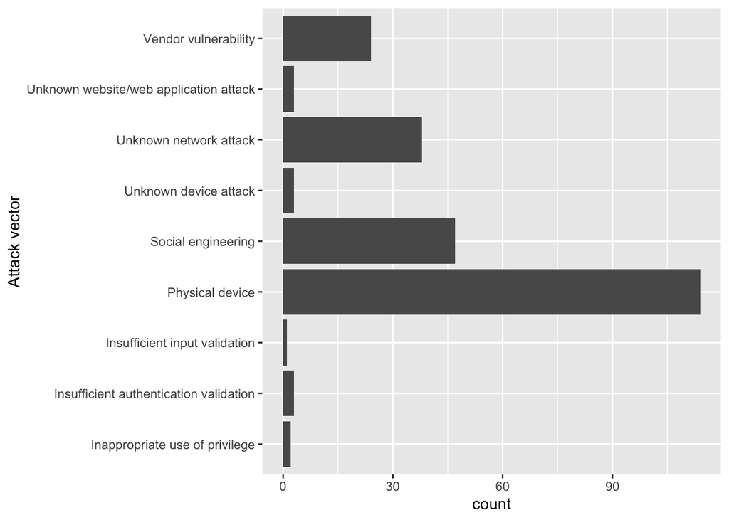

```r
#vettore d'attacco
health %>% filter(!is.na(`Attack vector`)) %>%
  ggplot(aes(y = `Attack vector`)) +
  geom_bar()
```

I grafici qua sopra dimostrano che il problema sta nel fattore umano, qundi nella mancanza di una corretta formazione e sensibilizzazione del personale su questi temi.

Infatti nella maggior parte dei casi l’attacco viene veicolato dai **device fisici** (periferiche infette, computer dei dipendenti infettati, …) a causa del loro furto, infatti, in secondo luogo, anche l’ **installazione di malware** è il tipo di attacco maggiormente utilizzato per attaccare il settore, ciò è dato dal fatto che molto spesso, l’installazione di malware e il furto di dispositivi fisici, o più in generale gli attacchi veicolati da essi, questi ultimi vengono usati come mezzo per iniziare l’infezione del sistema.

## Com’è cresciuto il volume di dati esfiltrati con il passare del tempo?

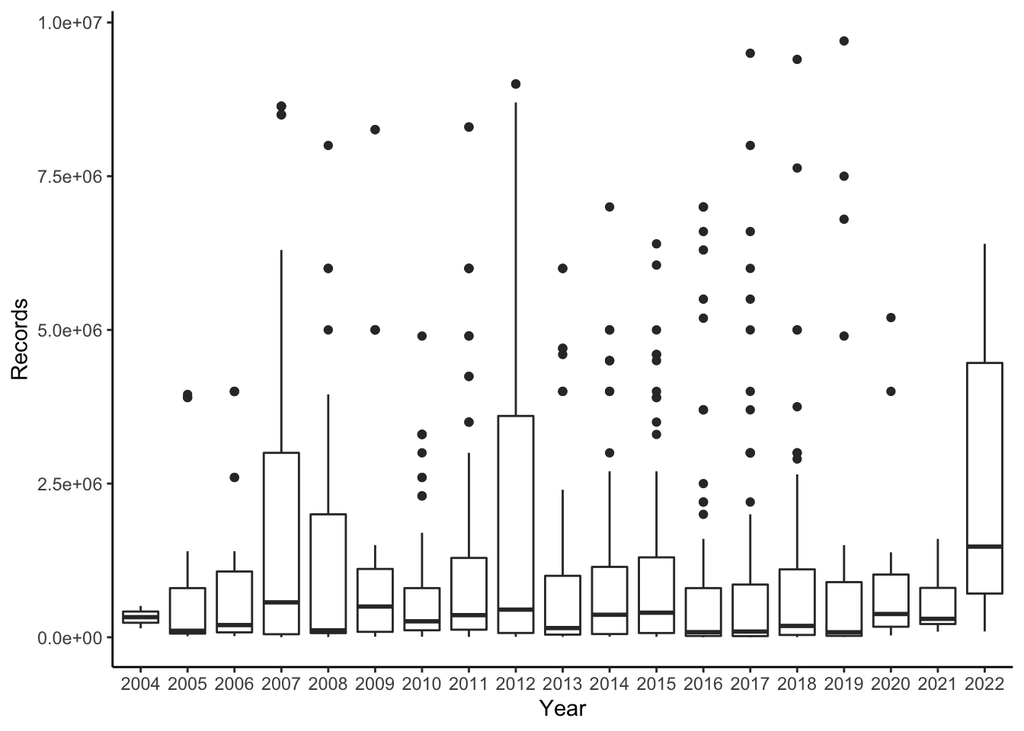

```r
attacks  %>% filter(Records < 10000000) %>%
  mutate(Year = as.character(Year)) %>%
  ggplot(aes(x = Year, y = Records, )) +
  geom_boxplot(na.rm = TRUE) +
  theme_classic()
```

Ora proviamo a vedere quale feature tra *dimensione dell’azienda*, *livello di digital intensity* e *sensibilità dei dati* vanno a influenzare il volume di dati rubati.

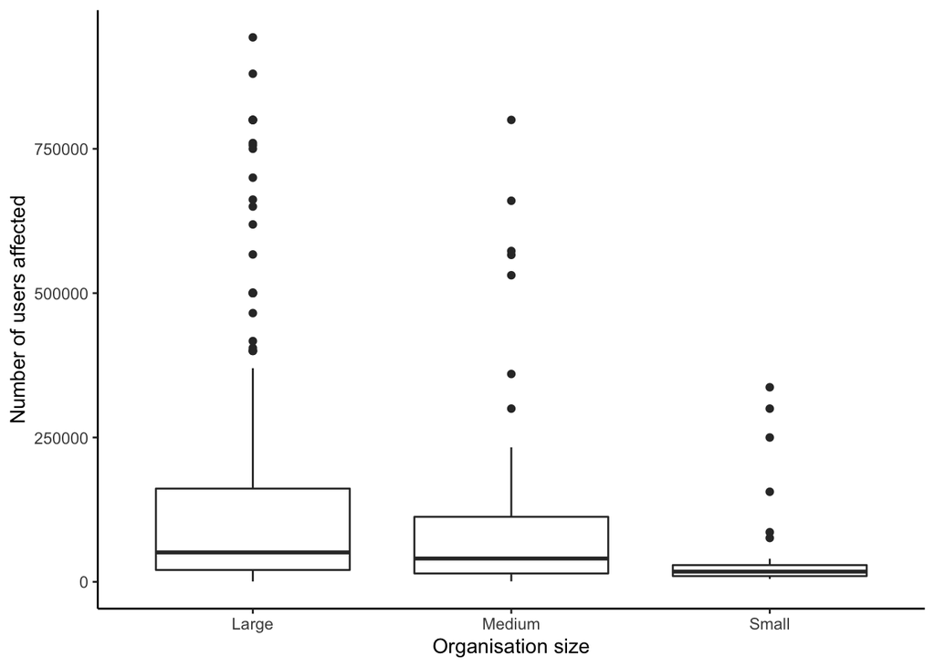

```r
#Organization size - Number of users affected
queensland  %>% filter(`Number of users affected` < 1000000 & !is.na(`Organisation size`)) %>%
  filter(!is.na(`Number of users affected`)) %>%
  ggplot(aes(x = `Organisation size`, y = `Number of users affected`), na.rm = TRUE) +
  geom_boxplot(na.rm = TRUE) +
  theme_classic()
```

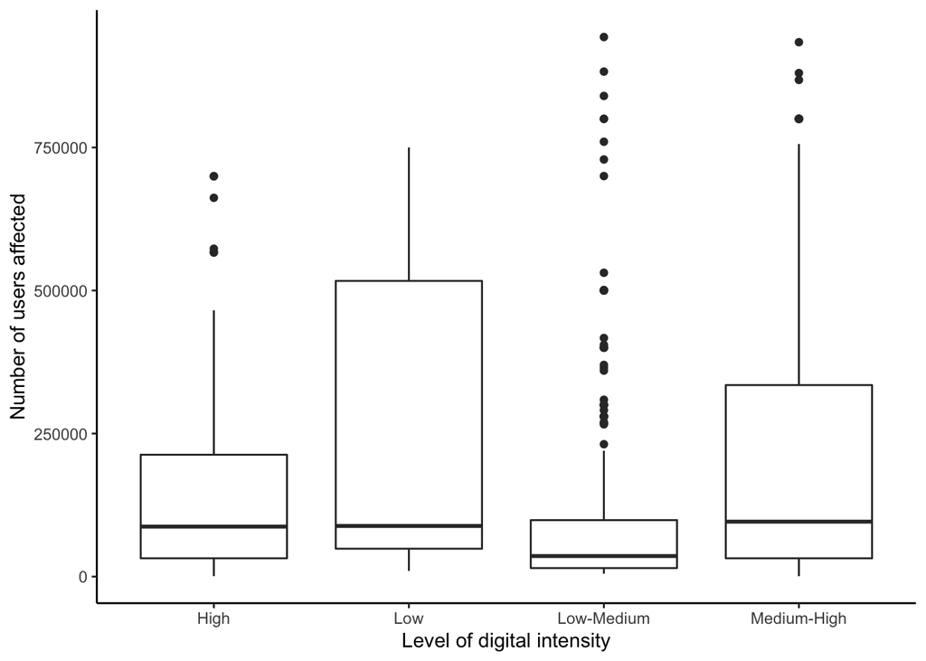

```r
# Level of digital intensity - Number of users affected
queensland  %>% filter(`Number of users affected` < 1000000) %>%
  ggplot(aes(x = `Level of digital intensity`, y = `Number of users affected`), na.rm = TRUE) +
  geom_boxplot(na.rm = TRUE) +
  theme_classic()
```

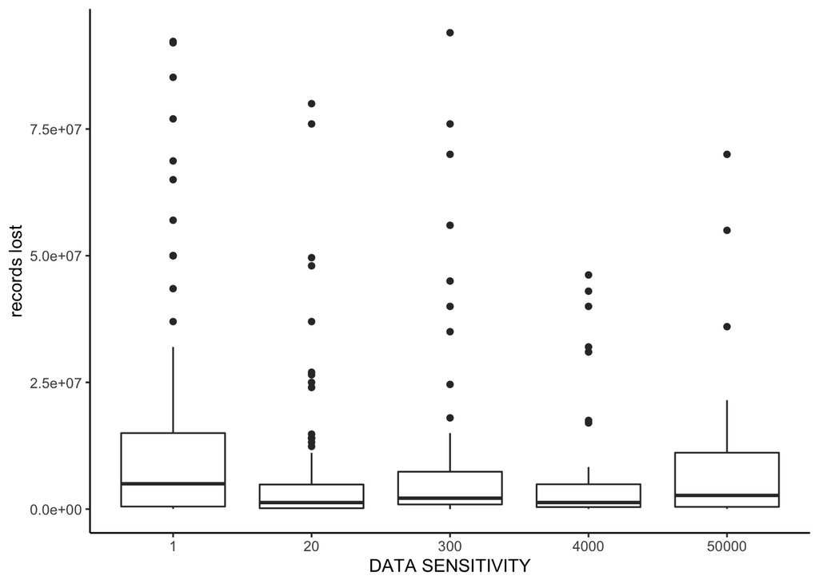

```r
# DATA SENSITIVITY - Number of users affected
data_breaches_2018_update  %>% mutate(`DATA SENSITIVITY` = as.character(`DATA SENSITIVITY`)) %>%
  filter(`records lost` < 100000000 & `DATA SENSITIVITY` != "3") %>%
  ggplot(aes(x = `DATA SENSITIVITY`, y = `records lost`), na.rm = TRUE) +
  geom_boxplot(na.rm = TRUE) +
  theme_classic()
```

Dai boxplot sopra descritti si nota che l’unica feature che va ad influire sulla quantità di records rubati è la dimensione dell’organizzazione: più grande è l’organizzazione, maggiore sarà la quntità di record rubati.

È stato scelto di prendere in considerazione solo le osservazioni con meno di 1000000, nei primi due e 100000000 nel terzo per riuscire a fornire una visualizzazione comprensibile e analizzabile.

I grafici non sono precisi al 100% per il fatto che è un analisi che è stata fatta su due dataset distinti e non sull’unione dei tre dataset perchè le features prese in considerazione appartengono a dataset distinti e non hanno tali features in comune.

## Che relazione esite tra sistemi di sicurezza implementati e le conseguenze di tale attacco?

Per scoprire se c’è un legame tra sistemi di sicurezza implemetati e le conseguenze dell’attacco devo verificare se esiste una correlazione. Per fare ciò trattandosi di varaibili qualitative, gli indici di correlazione visti per le variabili quantitative (Pearson, Kendal e Spearman) non sono applicabili quidi necessito un nuovo indice di correlazione: la **V di Cramer**.

In breve la **V di Crame** è un indice per valutare la correlazione tra variabili categoriali (o qualitative) nominale.

$$V = \sqrt {\frac{\chi ^ 2}{min(k-1,
r-1)\cdot n}}$$
dove χ<sup>2</sup> indica il **test chi quadro**, *n* indica le **osservazioni totali**, *k* indica il **numero di colonne** e *r* indica il **numero di righe**.

Il risultato è compreso tra **[0,1]**: con *0* si intende che tra le variabile non c’è alcuna correlazione e *1* indica che c’è un’alto livello di associazione, che può essere o positiva o negativa.

```r
sec_conseguences <- queensland %>% select(c(`Cyber security role` : `Absence of encryption`,
                                            `Restructuring after attack` : `Free identity or credit theft monitoring`,
                                            `Individual(s) name(s) leaked/exposed` : `Subsequent fraudulent use of data`,
                                            `Undertook investigation` : `Settlement paid`,
                                            -`Prevention, Detection and Recovery`))

sec_system <- sec_conseguences %>% select(c(`Cyber security role` : `Absence of encryption`,
                                            `Restructuring after attack` : `Free identity or credit theft monitoring`))
consequences <- sec_conseguences %>% select(c(`Individual(s) name(s) leaked/exposed` : `Subsequent fraudulent use of data`,
                                              `Undertook investigation` : `Settlement paid`))
```

Per calcolare la V di Cramer necessito di crare le **tabelle di contingenza** tra tutte le possibili coppie tramite la funzione ‘table()’ e su tale tabella vado a calcolare la V di Cramer, come mostrato qua di seguito.

```r
cramerV_table <-  matrix(0, nrow = 10, ncol = 13)
rownames(cramerV_table) <- c(names(sec_conseguences)[1 : 10])
colnames(cramerV_table) <- c(names(sec_conseguences)[11 : 23])

for (row in names(sec_conseguences)[1 : 10])
  for (col in names(sec_conseguences)[11 : 23])
    cramerV_table[row, col] <- cramerV(table(unlist(sec_conseguences[row]), unlist(sec_conseguences[col])))

cramerV_table <- as.data.frame(cramerV_table)

datatable(cramerV_table)
```

|  | Individual(s) name(s) leaked/exposed | Address(es) leaked/exposed | Other personally identifiable information (PII) leaked/exposed | Track 1 - Credit card details leaked/exposed | Track 2 - Credit card details leaked/exposed | Social security number/tax number leaked/exposed | Subsequent fraudulent use of data | Undertook investigation | Litigation by public | Penalties/settlement paid or actions imposed | Imposed penalties or actions on organisation | Fines issued by government or relevant body | Settlement paid |
| --- | --- | --- | --- | --- | --- | --- | --- | --- | --- | --- | --- | --- | --- |
| Cyber security role | 0.02415 | 0.008515 | 0.008021 | 0.03884 | 0.05067 | 0.04036 | 0.005983 | 0.07715 | 0.1601 | 0.1089 | 0.04221 | 0.1167 | 0.1097 |
| Cyber security frameworks | 0.006876 | 0.04231 | 0.02269 | 0.04637 | 0.004903 | 0.06166 | 0.029 | 0.02771 | 0.06462 | 0.01386 | 0.009752 | 0.01049 | 0.008829 |
| Education and awareness policy | 0.005612 | 0.03453 | 0.01892 | 0.022 | 0.004903 | 0.05033 | 0.01677 | 0.02262 | 0.009837 | 0.01131 | 0.007959 | 0.008558 | 0.007206 |
| Policy | 0.008781 | 0.0823 | 0.03011 | 0.04071 | 0.01081 | 0.05618 | 0.01211 | 0.0601 | 0.01568 | 0.03486 | 0.05936 | 0.0136 | 0.0114 |
| Improper network segmentation | 0.009898 | 0.001726 | 0.04615 | 0.1978 | 0.1024 | 0.2671 | 0.04068 | 0.1126 | 0.05717 | 0.001427 | 0.007907 | 0.02466 | 0.05685 |
| Inappropriate remote access | 0.04028 | 0.01958 | 0.002186 | 0.05211 | 0.03263 | 0.08914 | 0.02573 | 0.04038 | 0.03224 | 0.02666 | 0.02493 | 0.01483 | 0.02108 |
| Absence of encryption | 0.02472 | 0.01234 | 0.02923 | 0.103 | 0.02481 | 0.108 | 0.01253 | 0.04126 | 0.008722 | 0.0641 | 0.04115 | 0.0428 | 0.04646 |
| Restructuring after attack | 0.03102 | 0.02925 | 0.0007604 | 0.07659 | 0.01448 | 0.002972 | 0.009355 | 0.07461 | 0.05428 | 0.0188 | 0.03693 | 0.003672 | 0.01493 |
| Bribe/ransom paid | 0.007944 | 0.01856 | 0.01297 | 0.03615 | 0.009823 | 0.008123 | 0.02373 | 0.003368 | 0.01392 | 0.04274 | 0.06935 | 0.06327 | 0.0102 |
| Free identity or credit theft monitoring | 0.0907 | 0.1014 | 0.0244 | 0.05845 | 0.02022 | 0.2018 | 0.015 | 0.001325 | 0.0393 | 0.008414 | 0.03962 | 0.002512 | 0.02756 |

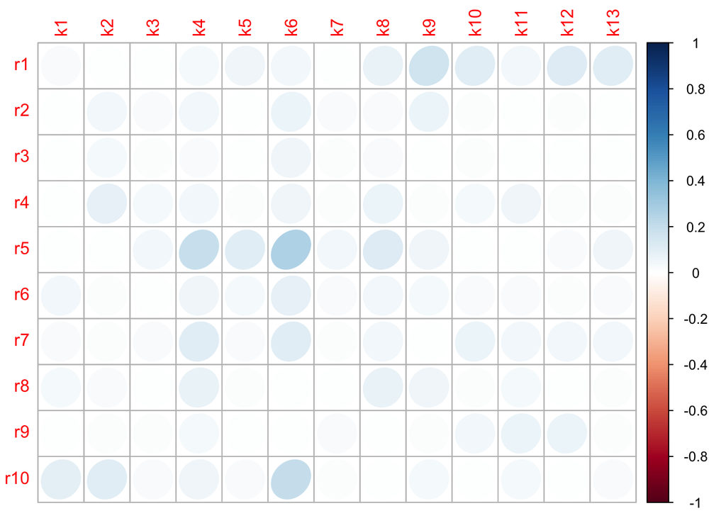

```r
corr_table <- as.matrix(cramerV_table)

rownames(corr_table) <- str_c("r", {1 : 10})
colnames(corr_table) <- str_c("k", {1 : 13})

corrplot(corr_table, method = "ellipse")
```

Per fornire la rappresentazione qua sopra ho dovuto rinominare le righe e colonne per riuscire a fornire una rappresentazione comprensibile e leggibile.

Andiamo a commentare più nello specifico alcune caratteristiche di sicurezza come vanno a influire sulle conseguenze dell’attacco: **assenza di cifrature** e **pagamento del riscatto**.

```r
datatable(cramerV_table["Absence of encryption", ])
```

|  | Individual(s) name(s) leaked/exposed | Address(es) leaked/exposed | Other personally identifiable information (PII) leaked/exposed | Track 1 - Credit card details leaked/exposed | Track 2 - Credit card details leaked/exposed | Social security number/tax number leaked/exposed | Subsequent fraudulent use of data | Undertook investigation | Litigation by public | Penalties/settlement paid or actions imposed | Imposed penalties or actions on organisation | Fines issued by government or relevant body | Settlement paid |
| --- | --- | --- | --- | --- | --- | --- | --- | --- | --- | --- | --- | --- | --- |
| Absence of encryption | 0.02472 | 0.01234 | 0.02923 | 0.103 | 0.02481 | 0.108 | 0.01253 | 0.04126 | 0.008722 | 0.0641 | 0.04115 | 0.0428 | 0.04646 |

Se si tiene in considerazione l’assenza o meno della cifratura sembra non essere determinante per evitare un eventuale data leak di qualunque tipo o evitare di pagare o ricevere multe rilasciate direttamete dal governo oppure enti competenti o qualunque altra azione imposta.

```r
datatable(cramerV_table["Bribe/ransom paid", ])
```

|  | Individual(s) name(s) leaked/exposed | Address(es) leaked/exposed | Other personally identifiable information (PII) leaked/exposed | Track 1 - Credit card details leaked/exposed | Track 2 - Credit card details leaked/exposed | Social security number/tax number leaked/exposed | Subsequent fraudulent use of data | Undertook investigation | Litigation by public | Penalties/settlement paid or actions imposed | Imposed penalties or actions on organisation | Fines issued by government or relevant body | Settlement paid |
| --- | --- | --- | --- | --- | --- | --- | --- | --- | --- | --- | --- | --- | --- |
| Bribe/ransom paid | 0.007944 | 0.01856 | 0.01297 | 0.03615 | 0.009823 | 0.008123 | 0.02373 | 0.003368 | 0.01392 | 0.04274 | 0.06935 | 0.06327 | 0.0102 |

Come ci si poteva aspettare, il pagamento del riscatto non assicura la non diffusione e la conseguente cancellazzione dei dati prelevati in modo illecito. Tale risultato dopo tutto era scontato per il fatto che l’accordo viene fatto con dei criminale di cui di base non ci si può fidare e non si ha nessun tipo di garanzia che mi assicura la cancellazione dei dati.

# CONCLUSIONI

In linea generale si può concludere che la sicurezza dei sistemi informatici deve partire dal minimizzare i rischi portati dal **fattore umano** con una buona campagna di sensibilizzazione ed educazione del personale su tali tematiche.